# Construção de mapas temáticos com o R

Ferramentas básicas para criar e editar mapas no R, sem a necessidade de softwares GIS

Data de Publicação

23 de outubro de 2026

# Pesquisador contribuidor

Esta prática foi gentilmente preparada pelo pesquisador parceiro *Igor Henrique Alves do Nascimento*.

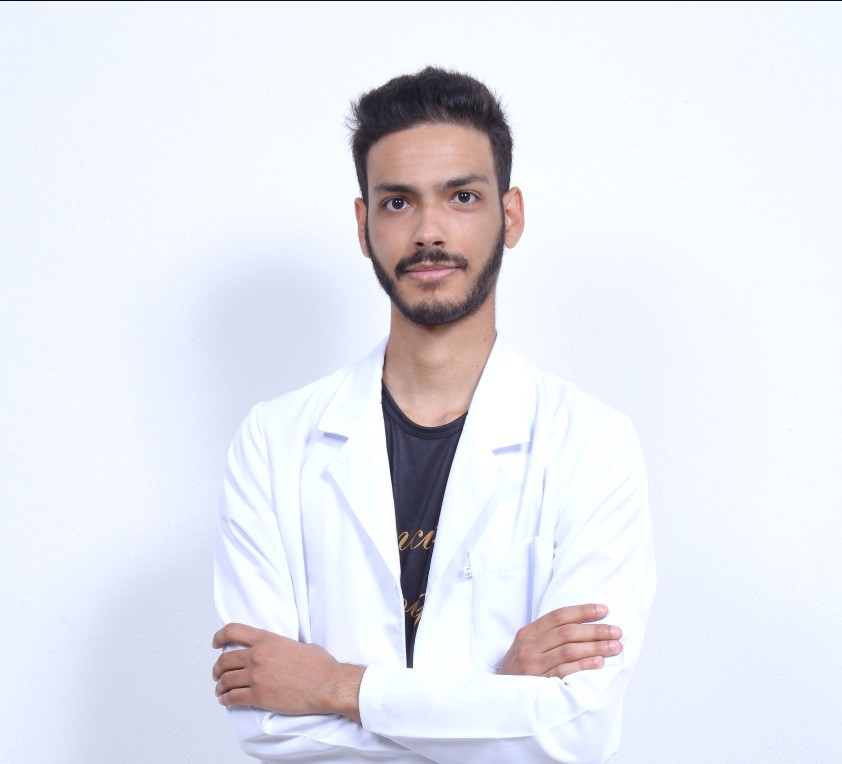

Mestre pelo Programa de **Pós-Graduação em Biologia de Vertebrados pela Pontifícia Universidade Católica de Minas Gerais** (PUC Minas - 2024) e integrante do **Laboratório de Genética da Conservação** da mesma instituição. Bacharel e Licenciado em Ciências Biológicas pela PUC Minas (2018-2022). Atualmente é doutorando em Biodiversidade e Meio Ambiente pela **PUC Minas**, com ênfase em ecologia do DNA ambiental em rios neotropicais. Possui interesse pelas áreas de Genética da Conservação, Biologia Molecular e Bioinformática.

[📄 Lattes](http://lattes.cnpq.br/8058057498186733)

[🧬 ORCID](https://orcid.org/0000-0002-7415-6417)

# Contextualização

A construção de mapas é fundamental para análises espaciais, permitindo representar e interpretar informações geográficas de forma visual e simplificada.

Para elaborar um mapa é necessário integrar dados espaciais (Shapefiles [.shp], rasters [.tif], tabelas [.csv]) a um sistema de informações geográficas (SIG), onde será possível tornar o mapa não apenas informativo, mas esteticamente agradável.

## Sistemas de Referências

Os sistemas de coordenadas geográficas são essenciais para localizar pontos na superfície geóide da terra. Quando representado a superfície terrestre em um plano (ex: mapas), é necessário aplicar uma projeção cartográfica específica para sua área de estudo, levando em consideração as deformações de área, formato ou distâncias de cada sistema.

### EPSG

Cada sistema de referência é padronizado por um código EPSG (*European Petroleum Survey Group*), que identifica e padroniza os sistemas de coordenadas. Por exemplo:

- EPSG:4326 - WGS84 (Usado globalmente e em GPS)
- EPSG:4674 - SIRGAS 2000 (Oficial do Brasil)
- EPSG:31983 - UTM Zona 23S, baseado em SIRGAS 2000 (Utilizado no Sudeste Brasileiro)

# Prática

Baixar o script desta prática (.R)

## Carregar pacotes necessários

```r
{
  library(sf)
  library(terra)
  library(ggspatial)
  library(ggplot2)
  library(dplyr)
}
```

## Definindo seu diretório de trabalho

Para cada projeto, sempre crie uma pasta onde você vai salvar todos arquivos e scripts, assim você mantém seu trabalho sempre organizado. No comando abaixo, coloque dentro das aspas o caminho para o seu diretório de trabalho.

```r
getwd()

setwd("")
# utilize o tab para autocompletar com o cursor entre as aspas
```

## Obtenção de dados brutos

Existem diversos bancos de dados de informação cartográfica com shapefiles e raster de diversos locais e temas. Para MG por exemplo, podemos acessar o portal da Secretaria de Estado de Meio Ambiente e Desenvolvimento Sustentável (SEMAD) através do banco de dados [IDE-Sisema](https://visualizador.idesisema.meioambiente.mg.gov.br/).

Nesse banco é possível baixar arquivos .shp de diversos tipos, para o estado de MG. Para esta prática iremos utilizar a base de dados:

Restrição Ambiental > Áreas Protegidas > Unidades de Conservação Estaduais

Limites > Unidade da Federação > Limite de Minas Gerais

Em seguida, você poderá carregar os dados para o R

## Dados para está prática

### Baixar e descompactar shapes

```r
# abixar aruivos
download.file("https://github.com/heronoh/bioinfo/blob/main/aulas/r/arquivos/maps.tar.gz",
              destfile = "maps.tar.gz", mode = "wb")


#descompactar arquivos ----
untar("maps.tar.gz", exdir = ".")
```

### Ler arquivos

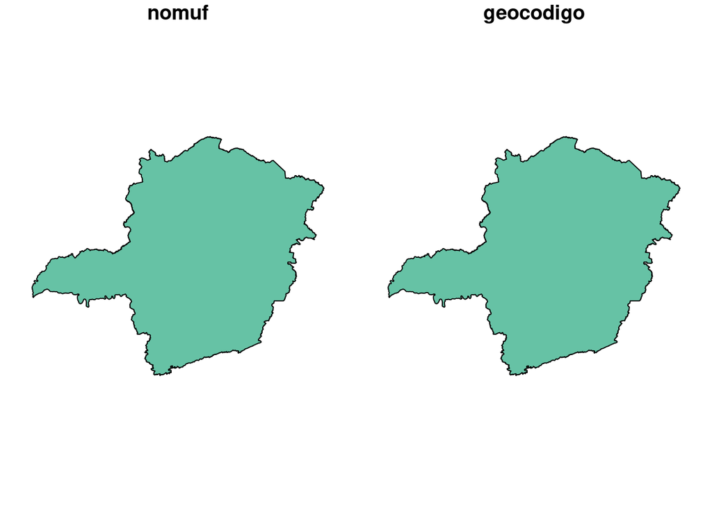

```r
# MG
minas <- st_read("ide_1101_mg_unidade_federacao_pol.shp")
plot(minas)
```

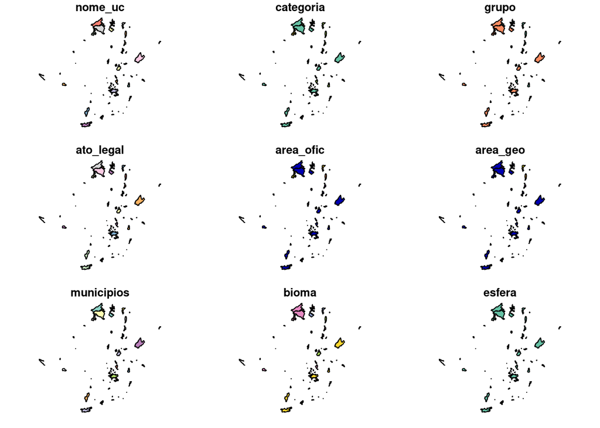

```r
# Parques
# uc_minas <- st_read("/PASTA/SUA_UC.shp")
uc_minas <- st_read("ide_2010_mg_unidades_conservacao_estaduais_pol.shp")
plot(uc_minas)
```

Note que o arquivo de UCs possui mais de uma área dividida em diversas categorias.

Vamos selecionar apenas a área de interesse:

```r
uc_minas$categoria %>% unique()
```

```
[1] "PAR"   "APA"   "REBIO" "FLOE"  "MONA"  "ESEC"  "RVS"   "RDS"
```

```r
# é possível filtrar por qualquer valor desejado, exemplos:

uc_interesse <- uc_minas %>%
  dplyr::filter(categoria == "PAR")
  # dplyr::filter(bioma == "Mata Atlantica")
  # dplyr::filter(nome == "Parque Estadual da Serra do Cipo")
```

Com todos os .shp selecionados, precisamos converter as camadas para o mesmo sistema de coordenadas:

```r
minas_wgs <- sf::st_transform(x = minas,
                              crs = 4326)

uc_minas_wgs <- sf::st_transform(x = uc_minas,
                                 crs = 4326)

uc_int_wgs <- sf::st_transform(x = uc_interesse,
                               crs = 4326)
```

## Plotar o mapa final

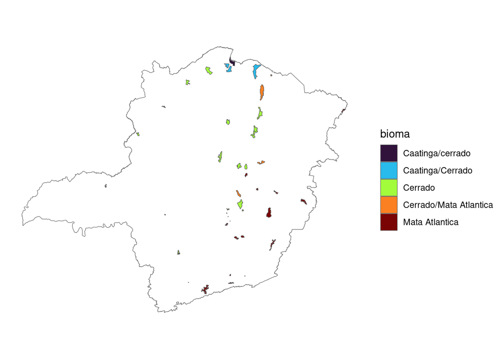

```r
ggplot()+
  geom_sf(data = uc_int_wgs,
          aes(fill = bioma))+
  scale_fill_viridis_d(option = "turbo")+
  geom_sf(data = minas_wgs,
          fill = "transparent")+
  theme_minimal()+
  theme(axis.line = element_blank(),
        axis.text = element_blank(),
        axis.ticks = element_blank(),
        panel.grid = element_blank(),
        plot.background = element_rect(fill = "white",
                                       color = NA),
        panel.background = element_rect(fill = "white",
                                        color = NA),
        panel.border = element_blank())
```

## Trabalhando com Rasters

Rasters são imagens pixeladas, que trazem informações mais complexas para o geoprocessamento.

Cada pixel da imagem possui tamanhos pré-definidos, de acordo com a metodologia abordada em sua produção. Quanto menor o tamanho dos pixels, mais detalhada a imagem será, por exemplo rasters de 30 metros por pixel possuem alta resolução.

### Visualizando rasters

Utilizaremos dados de temperatura média anual, disponível na plataforma WorldClim.

Você pode baixar o arquivo recortado para o estado de Minas Gerais aqui.

```r
raster_temp <- terra::rast("wc2.1_30s_bio_1_cortado.tif")
```

- Para visualizar o raster, antes é necessário transformá-lo em um dataframe

```r
raster_temp_df <- as.data.frame(x = raster_temp,
                                xy = TRUE)

# renomear a coluna de valores do raster
names(raster_temp_df)[3] <- "value"
```

### Plotar o mapa temático final

- Vamos criar um mapa da bacia do Rio Doce, com os rios e dados de ocorrência de uma espécie de peixe, disponíveis no SpeciesLink.

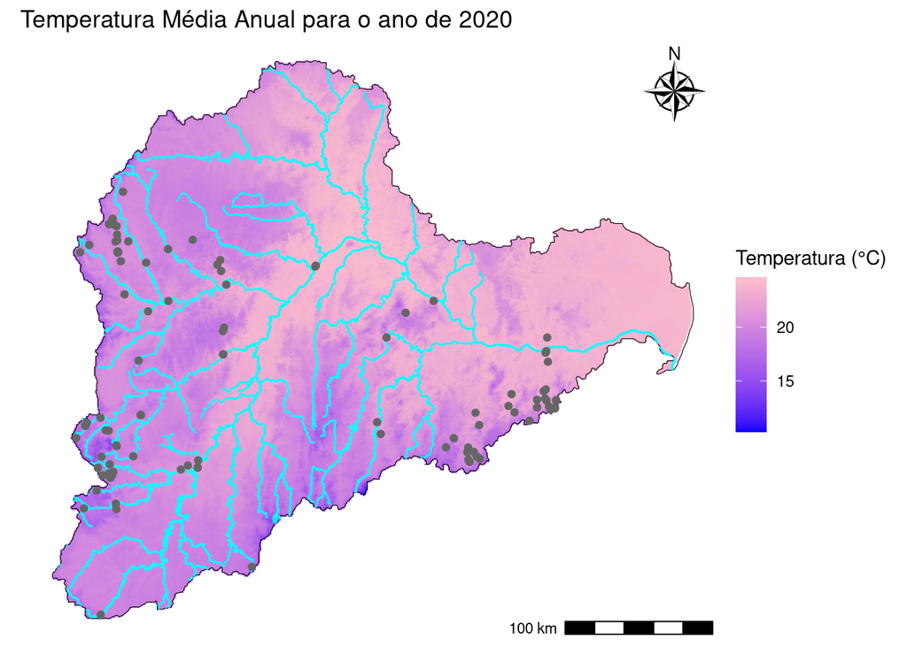

```r
# ler shp
bacia <- st_read("bacia_doce.shp")
rios <- st_read("rios_intersec.shp")
# definir projeção
bacia_wgs <- st_set_crs(x = bacia,
                        value = 4326)

# reprojetar para coordenada certa
rios_wgs <- st_transform(x = rios,
                         crs = 4326)

# Carregar dados a partir de um .csv
ocur_peixes <- read.csv("banco_final_tricho.csv")

# transformar csv em shp
ocur_peixe_shp <- st_as_sf(ocur_peixes,
                           coords = c("long",
                                      "lat"), crs = 4326)

# cortar dados apenas para a área de interesse
peixes_inter <- st_intersection(ocur_peixe_shp, bacia_wgs)

# plotar o mapa
ggplot()+
  geom_raster(data = raster_temp_df,
              aes(x = x,
                  y = y,
                  fill = value))+
  scale_fill_gradient(low = "blue", high = "pink", name = "Temperatura (°C)")+
  geom_sf(data = bacia_wgs,
          color = "black",
          fill = "transparent") +
  geom_sf(data = rios_wgs,
          color = "cyan") +
  geom_sf(data = peixes_inter,
          color = "grey40") +
  annotation_north_arrow(location = "tr",
                         which_north = "true",
                         # pad_x = unit(8, "cm"),
                         # pad_y = unit(5, "cm"),
                         style = north_arrow_nautical()) + # elemento obrigatorio
  annotation_scale(location = "br",
                   # pad_x = ,
                   # pad_y = ,
                   width_hint = 0.3) +
  theme_void() +
  labs(title = "Temperatura Média Anual para o ano de 2020")
```